# Chapter 4 - Clustering and classification

In this chapter we are going to explore one of R’s own data “Boston” of the package MASS. The dataset covers many housing-related topics such as crime rate, taxes, race and pupil-teacher ratio. The primary units of the data are the suburbs of Boston.

First, let’s discover the structure of the data.

```r
data("Boston")

dim(Boston)
```

```
## [1] 506  14
```

```r
str(Boston)
```

```
## 'data.frame':    506 obs. of  14 variables:
##  $ crim   : num  0.00632 0.02731 0.02729 0.03237 0.06905 ...
##  $ zn     : num  18 0 0 0 0 0 12.5 12.5 12.5 12.5 ...
##  $ indus  : num  2.31 7.07 7.07 2.18 2.18 2.18 7.87 7.87 7.87 7.87 ...
##  $ chas   : int  0 0 0 0 0 0 0 0 0 0 ...
##  $ nox    : num  0.538 0.469 0.469 0.458 0.458 0.458 0.524 0.524 0.524 0.524 ...
##  $ rm     : num  6.58 6.42 7.18 7 7.15 ...
##  $ age    : num  65.2 78.9 61.1 45.8 54.2 58.7 66.6 96.1 100 85.9 ...
##  $ dis    : num  4.09 4.97 4.97 6.06 6.06 ...
##  $ rad    : int  1 2 2 3 3 3 5 5 5 5 ...
##  $ tax    : num  296 242 242 222 222 222 311 311 311 311 ...
##  $ ptratio: num  15.3 17.8 17.8 18.7 18.7 18.7 15.2 15.2 15.2 15.2 ...
##  $ black  : num  397 397 393 395 397 ...
##  $ lstat  : num  4.98 9.14 4.03 2.94 5.33 ...
##  $ medv   : num  24 21.6 34.7 33.4 36.2 28.7 22.9 27.1 16.5 18.9 ...
```

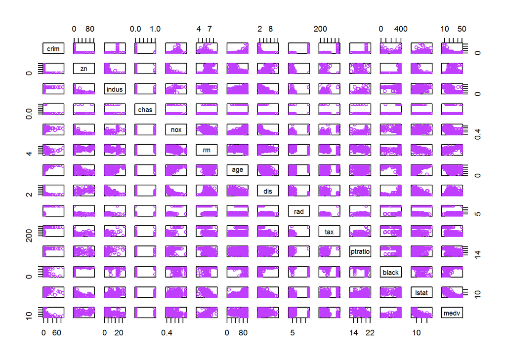

```r
pairs(Boston, col="darkorchid1")
```

We see that there are 506 observations of 14 variables that are mostly numerical. Scatterplots of every variable pair of the data can be seen in the pairs-plot. It is clearly visible that only the variable “chas” is dichotomous with values 0 and 1. The inside pairs correlations or connections differ quite much from each other.

The variable “crim” describes the per capita crime rate by town. Below the summary shows that the crime rate has a large variance. Maybe a better picture of the structure of it we get from the graphical performance. In the scatterplot we have the crime rate on y-axis and it is compared to the median value of owner-occupied homes, variable “medv” in the data. The maximum value of crime rate (88.98) seems to be an outlier better than descriptive data point, because most of the observations are from 0 to about 25. There is some linearity between the home median value and crime rate, but not at the maximum point. It is interesting that when “medv” has it’s max value (50), suddenly crime rate gets also increased values. This would mean that in the towns where median value of owner-occupied homes is $50 000, the per capita crime rate is higher than for lower median values between 30 and >50.

```r
summary(Boston$medv)
```

```
##    Min. 1st Qu.  Median    Mean 3rd Qu.    Max.
##    5.00   17.02   21.20   22.53   25.00   50.00
```

```r
summary(Boston$crim)
```

```
##     Min.  1st Qu.   Median     Mean  3rd Qu.     Max.
##  0.00632  0.08204  0.25650  3.61400  3.67700 88.98000
```

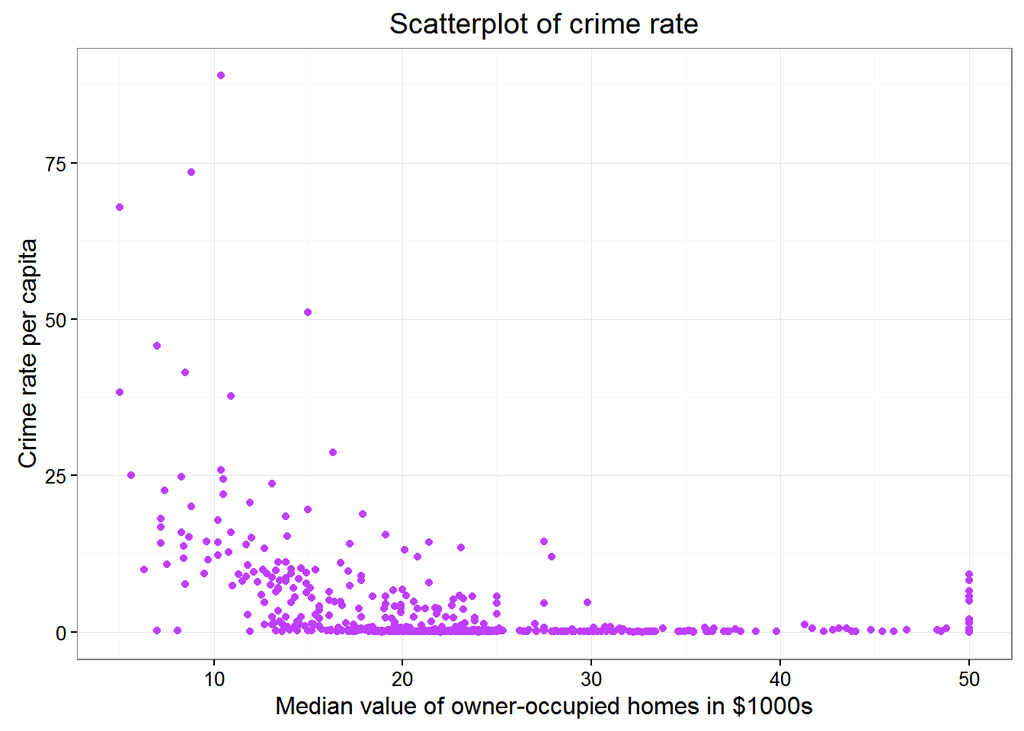

```r
p <- ggplot(Boston, aes(x=medv, y=crim)) + geom_point(col="darkorchid1") + ylab("Crime rate per capita") + xlab("Median value of owner-occupied homes in $1000s") + ggtitle("Scatterplot of crime rate")
p + theme_bw()
```

Before linear discriminant analysis we must scale the data and divide it to two subsets; test set and train set. First the scaling;

```r
boston_scaled <- scale(Boston)
boston_scaled <- as.data.frame(boston_scaled)

summary(boston_scaled)
```

```
##       crim                 zn               indus
##  Min.   :-0.419367   Min.   :-0.48724   Min.   :-1.5563
##  1st Qu.:-0.410563   1st Qu.:-0.48724   1st Qu.:-0.8668
##  Median :-0.390280   Median :-0.48724   Median :-0.2109
##  Mean   : 0.000000   Mean   : 0.00000   Mean   : 0.0000
##  3rd Qu.: 0.007389   3rd Qu.: 0.04872   3rd Qu.: 1.0150
##  Max.   : 9.924110   Max.   : 3.80047   Max.   : 2.4202
##       chas              nox                rm               age
##  Min.   :-0.2723   Min.   :-1.4644   Min.   :-3.8764   Min.   :-2.3331
##  1st Qu.:-0.2723   1st Qu.:-0.9121   1st Qu.:-0.5681   1st Qu.:-0.8366
##  Median :-0.2723   Median :-0.1441   Median :-0.1084   Median : 0.3171
##  Mean   : 0.0000   Mean   : 0.0000   Mean   : 0.0000   Mean   : 0.0000
##  3rd Qu.:-0.2723   3rd Qu.: 0.5981   3rd Qu.: 0.4823   3rd Qu.: 0.9059
##  Max.   : 3.6648   Max.   : 2.7296   Max.   : 3.5515   Max.   : 1.1164
##       dis               rad               tax             ptratio
##  Min.   :-1.2658   Min.   :-0.9819   Min.   :-1.3127   Min.   :-2.7047
##  1st Qu.:-0.8049   1st Qu.:-0.6373   1st Qu.:-0.7668   1st Qu.:-0.4876
##  Median :-0.2790   Median :-0.5225   Median :-0.4642   Median : 0.2746
##  Mean   : 0.0000   Mean   : 0.0000   Mean   : 0.0000   Mean   : 0.0000
##  3rd Qu.: 0.6617   3rd Qu.: 1.6596   3rd Qu.: 1.5294   3rd Qu.: 0.8058
##  Max.   : 3.9566   Max.   : 1.6596   Max.   : 1.7964   Max.   : 1.6372
##      black             lstat              medv
##  Min.   :-3.9033   Min.   :-1.5296   Min.   :-1.9063
##  1st Qu.: 0.2049   1st Qu.:-0.7986   1st Qu.:-0.5989
##  Median : 0.3808   Median :-0.1811   Median :-0.1449
##  Mean   : 0.0000   Mean   : 0.0000   Mean   : 0.0000
##  3rd Qu.: 0.4332   3rd Qu.: 0.6024   3rd Qu.: 0.2683
##  Max.   : 0.4406   Max.   : 3.5453   Max.   : 2.9865
```

Scaling the data affected in the level of the variables; now every variable has the mean of 0. Thus they all vary in both sides of the same mean value.

Next we are going to create a categorical variable of the variable “crim” in our scaled data. This is done by using the quantiles as the break points in the categorical variable.

```r
scaled_crim <- boston_scaled$crim

# a quantile vector of crim
bins <- quantile(scaled_crim)

# creating the categorical variable
crime <- cut(scaled_crim, breaks = bins, include.lowest = TRUE, labels = c("low", "med_low", "med_high", "high"))

table(crime)
```

```
## crime
##      low  med_low med_high     high
##      127      126      126      127
```

```r
# removing original crim from the dataset
boston_scaled <- dplyr::select(boston_scaled, -crim)

# adding the new categorical value to scaled data
boston_scaled <- data.frame(boston_scaled, crime)
```

Now let’s divide the data to train and test sets.

```r
# number of rows
n <- nrow(boston_scaled)

# choosing 80% of the rows
ind <- sample(n,  size = n * 0.8)

# train set
train <- boston_scaled[ind,]

# test set
test <- boston_scaled[-ind,]
```

Now, we will run the linear discriminant analysis using the categorical crime rate as the target variable and all the other variables as predictors.

```r
# linear discriminant analysis
lda.fit <- lda(crime ~ ., data = train)

# print the lda.fit object
lda.fit
```

```
## Call:
## lda(crime ~ ., data = train)
##
## Prior probabilities of groups:
##       low   med_low  med_high      high
## 0.2574257 0.2400990 0.2475248 0.2549505
##
## Group means:
##                  zn      indus         chas        nox          rm
## low       0.9256439 -0.8977938 -0.158758869 -0.8709853  0.43659601
## med_low  -0.0991358 -0.3074705  0.011791568 -0.5638207 -0.14046945
## med_high -0.4006284  0.1600823  0.278864965  0.3580063  0.04400065
## high     -0.4872402  1.0170891 -0.004759149  1.0745688 -0.35743398
##                 age        dis        rad        tax     ptratio
## low      -0.8517525  0.8473181 -0.6848158 -0.7269378 -0.44802821
## med_low  -0.3890822  0.3715781 -0.5461641 -0.4941861 -0.04374653
## med_high  0.3925594 -0.3736557 -0.4225678 -0.3322541 -0.28847543
## high      0.8217357 -0.8547060  1.6384176  1.5142626  0.78111358
##                black       lstat        medv
## low       0.37320436 -0.74450063  0.52000915
## med_low   0.31506034 -0.12807755 -0.03383205
## med_high  0.07721539  0.01788764  0.14702385
## high     -0.82560767  0.89189439 -0.70957229
##
## Coefficients of linear discriminants:
##                 LD1         LD2         LD3
## zn       0.09290551  0.70625309 -0.92072719
## indus    0.08708651 -0.18954172  0.34221175
## chas    -0.08594519 -0.10182730  0.11791382
## nox      0.40799119 -0.68792695 -1.21785794
## rm      -0.12062969 -0.01639906 -0.03355328
## age      0.20485405 -0.29588340 -0.30824226
## dis      0.02003064 -0.19978993  0.25390585
## rad      3.34214555  1.04758565 -0.19135907
## tax      0.07534271 -0.16757101  0.61712890
## ptratio  0.13921683  0.02042422 -0.15804126
## black   -0.10067320  0.03150028  0.14742439
## lstat    0.24144171 -0.22292434  0.48512420
## medv     0.20323614 -0.40784555 -0.24516826
##
## Proportion of trace:
##    LD1    LD2    LD3
## 0.9574 0.0320 0.0106
```

From the results we see for example the propabilities for every group of the variable “crime”, then group means and propabilities for every ld model. We see that R has constructed three ld groups, which is one less than the groups of “crime”.

Let’s then draw the LDA biplot with informative arrows. We use colour groups that are our ld model classes.

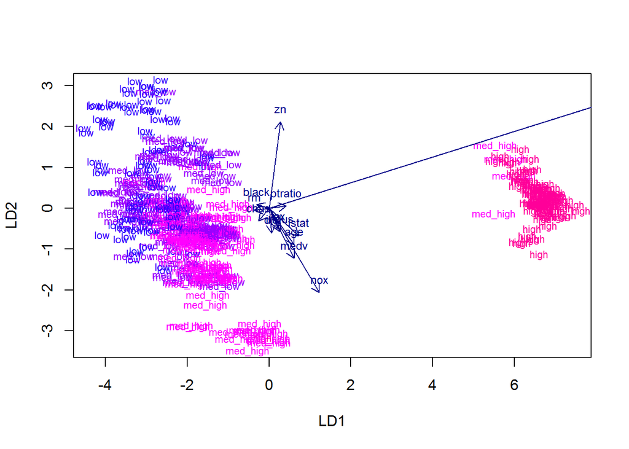

```r
# lda biplot arrows
lda.arrows <- function(x, myscale = 1, arrow_heads = 0.1, color = "red", tex = 0.75, choices = c(1,2)){
  heads <- coef(x)
  arrows(x0 = 0, y0 = 0,
         x1 = myscale * heads[,choices[1]],
         y1 = myscale * heads[,choices[2]], col=color, length = arrow_heads)
  text(myscale * heads[,choices], labels = row.names(heads),
       cex = tex, col=color, pos=3)
}

# target classes as numeric
classes <- as.numeric(train$crime)

plot(lda.fit, dimen = 2, col=rainbow(4, start = 0.7, end = 0.9)[classes], pch=classes)
lda.arrows(lda.fit, myscale = 3, col="darkblue")
```

Before we can use the test data for some further predictions, we should save the crime categories from the test data and then remove the categorical crime variable.

```r
# saving the correct classes from test set
correct_classes <- test$crime

# removing the crime variable from test data
test <- dplyr::select(test, -crime)
```

Now we will predict the classes with the LDA model and cross tabulate the results with the crime categories from the test set.

```r
lda.pred <- predict(lda.fit, newdata = test)

table(correct = correct_classes, predicted = lda.pred$class)
```

```
##           predicted
## correct    low med_low med_high high
##   low       19       3        1    0
##   med_low    6      16        7    0
##   med_high   0       4       20    2
##   high       0       0        0   24
```

We can now move on to the most interesting part of the chapter, K-means clustering. For this we reload the Boston dataset and standardize it. After that we can calculate distance measures using the euklidean and manhattan distance.

```r
data("Boston")

boston_stand <- scale(Boston)
boston_stand <- as.data.frame(boston_stand)

# Euklidean distance
dist_eu <- dist(boston_stand)
summary(dist_eu)
```

```
##    Min. 1st Qu.  Median    Mean 3rd Qu.    Max.
##  0.1343  3.4620  4.8240  4.9110  6.1860 14.4000
```

```r
# Manhattan distance
dist_man <- dist(boston_stand, method="manhattan")
summary(dist_man)
```

```
##    Min. 1st Qu.  Median    Mean 3rd Qu.    Max.
##  0.2662  8.4830 12.6100 13.5500 17.7600 48.8600
```

Using the euklidean distance measure we run the k-means clustering algorithm on the data. To find the optimal number of clusters we can investigate the within cluster sum of squares (WCSS) measure by drawing a plot of the total WCSS values for each number of clusters.

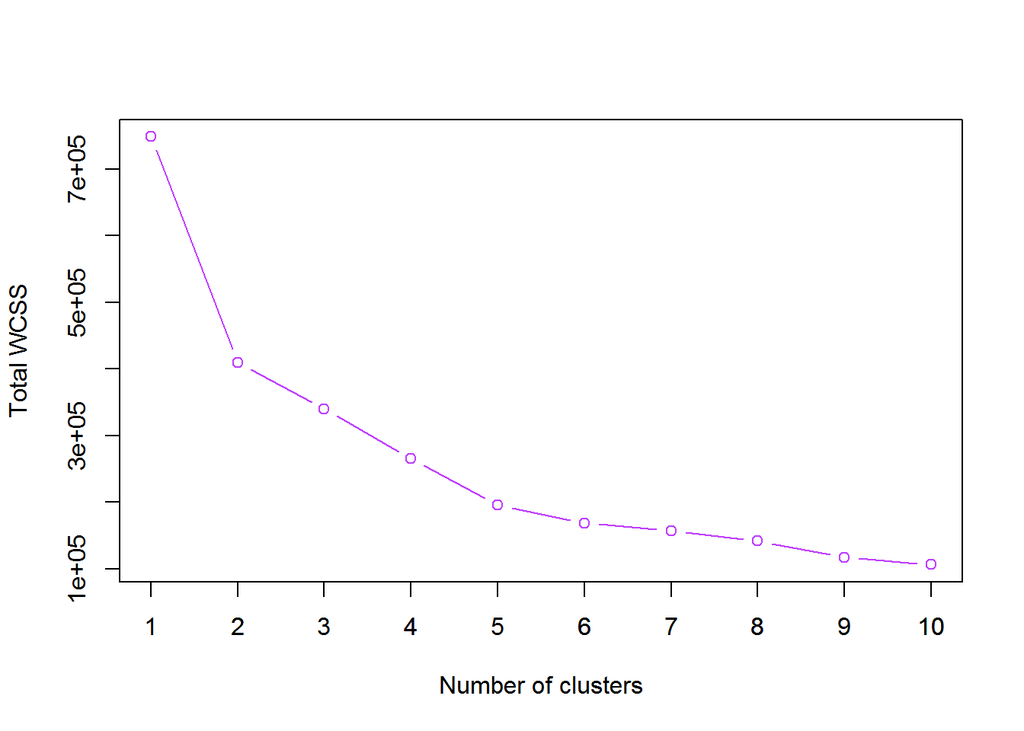

```r
set.seed(123)

# The total within sum of squares
k_max <- 10
twcss <- sapply(1:k_max, function(k){kmeans(dist_eu, k)$tot.withinss})

# visualize the results
plot(1:k_max, twcss, type='b', col="darkorchid1", xlab="Number of clusters", ylab="Total WCSS")
axis(1, at=1:10)
```

```r
km <-kmeans(dist_eu, centers = 4)
```

We find that the most radical change in WCSS is when there are 2 clusters. So we will try K-means with 2 centers.

```r
km1 <-kmeans(dist_eu, centers = 2)
```

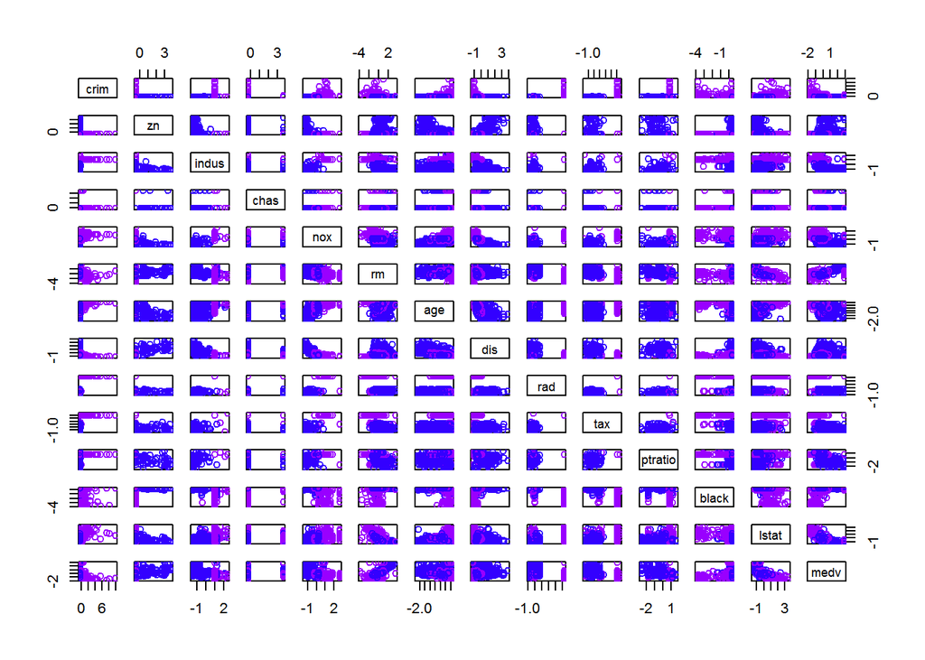

```r
pairs(boston_stand, col=rainbow(4, start = 0.7, end = 0.9)[km1$cluster])
```